# Survival Analysis of a Randomised Cancer Trial

Does adjuvant chemotherapy delay recurrence and prolong survival in colon cancer?

Kingsley Amegah

June 2026

# 1 Background and question

A central job of data science in health is to answer one question rigorously: **does a treatment actually work, and for whom?** The cleanest evidence comes from a randomised controlled trial (RCT), where patients are assigned to treatments by chance so the groups are comparable.

This report analyses a real, published RCT: the **colon cancer adjuvant-therapy trial** (Moertel and colleagues). After surgery, **929 patients** with stage B or C colon cancer were randomly assigned to one of three arms:

- **Obs**, observation only (the control),
- **Lev**, levamisole,
- **Lev+5FU**, levamisole plus fluorouracil.

Two outcomes were followed over time: **recurrence** of the cancer and **death**. The analytical challenge is that many patients had not had the event by the end of follow-up (their times are *censored*), so ordinary averages do not work. This is what **survival analysis** is built for.

# 2 The data and randomisation check

Because treatment was randomised, the arms should look similar at baseline. A balance table is the first thing a trial statistician checks.

```r
bt <- os |>
  select(rx, age, sex, nodes, node4, differ, extent, obstruct, perfor) |>
  tbl_summary(by = rx,
              label = list(age ~ "Age (years)", nodes ~ "Positive nodes",
                           node4 ~ "Nodal burden", differ ~ "Differentiation",
                           extent ~ "Local extent", obstruct ~ "Obstruction",
                           perfor ~ "Perforation", sex ~ "Sex"),
              digits = all_categorical() ~ c(0, 1)) |>
  add_p(pvalue_fun = ~ style_pvalue(.x, digits = 3)) |>
  modify_header(label ~ "**Characteristic**") |>
  modify_caption("**Table 1. Baseline characteristics by treatment arm**")
cat(strip_dash(as_kable(bt)), sep = "\n")
```

**Table 1. Baseline characteristics by treatment arm**

| **Characteristic** | **Obs** N = 315 | **Lev** N = 310 | **Lev+5FU** N = 304 | **p-value** |
| --- | --- | --- | --- | --- |
| Age (years) | 60 (53, 68) | 61 (53, 69) | 62 (52, 70) | 0.804 |
| Sex |  |  |  | 0.028 |
| Female | 149 (47.3%) | 133 (42.9%) | 163 (53.6%) |  |
| Male | 166 (52.7%) | 177 (57.1%) | 141 (46.4%) |  |
| Positive nodes | 2 (1, 5) | 2 (1, 5) | 2 (1, 4) | 0.550 |
| Unknown | 3 | 6 | 9 |  |
| Nodal burden |  |  |  | 0.749 |
| 1-3 nodes | 228 (72.4%) | 221 (71.3%) | 225 (74.0%) |  |
| >4 nodes | 87 (27.6%) | 89 (28.7%) | 79 (26.0%) |  |
| Differentiation |  |  |  | 0.522 |
| Moderate | 229 (74.4%) | 219 (73.0%) | 215 (72.1%) |  |
| Poor | 52 (16.9%) | 44 (14.7%) | 54 (18.1%) |  |
| Well | 27 (8.8%) | 37 (12.3%) | 29 (9.7%) |  |
| Unknown | 7 | 10 | 6 |  |
| Local extent |  |  |  | 0.264 |
| Contiguous | 20 (6.3%) | 12 (3.9%) | 11 (3.6%) |  |
| Muscle | 38 (12.1%) | 36 (11.6%) | 32 (10.5%) |  |
| Serosa | 249 (79.0%) | 259 (83.5%) | 251 (82.6%) |  |
| Submucosa | 8 (2.5%) | 3 (1.0%) | 10 (3.3%) |  |
| Obstruction | 63 (20.0%) | 63 (20.3%) | 54 (17.8%) | 0.683 |
| Perforation | 9 (2.9%) | 10 (3.2%) | 8 (2.6%) | 0.907 |

# 3 Kaplan-Meier survival curves

The Kaplan-Meier estimator turns censored follow-up times into a survival curve: the share of patients still event-free as time passes. We compare arms with the **log-rank test**.

## 3.1 Overall survival (time to death)

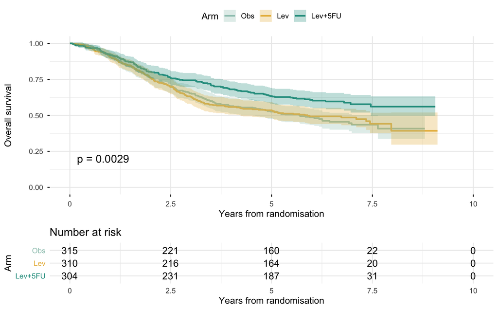

```r
fit_os <- survfit(Surv(time_yrs, status) ~ rx, data = os)
ggsurvplot(fit_os, data = os, palette = PAL, conf.int = TRUE,
           risk.table = TRUE, pval = TRUE, censor = FALSE,
           xlab = "Years from randomisation", ylab = "Overall survival",
           legend.title = "Arm", legend.labs = c("Obs", "Lev", "Lev+5FU"),
           risk.table.height = 0.28, ggtheme = theme_minimal(base_size = 12))
```

```r
lr_os <- survdiff(Surv(time_yrs, status) ~ rx, data = os)
p_os <- 1 - pchisq(lr_os$chisq, df = length(lr_os$n) - 1)
med <- summary(fit_os)$table[, "median"]
cat("Log-rank p-value (overall survival):", signif(p_os, 3), "\n")
```

```
## Log-rank p-value (overall survival): 0.0029
```

```r
cat("Median survival not reached where shown as NA (over half still alive).\n")
```

```
## Median survival not reached where shown as NA (over half still alive).
```

```r
print(round(med, 2))
```

```
##     rx=Obs     rx=Lev rx=Lev+5FU
##       5.70       5.89         NA
```

Overall survival was highest in the levamisole-plus-fluorouracil arm, whose Kaplan-Meier curve lay consistently above those of the observation and levamisole-only arms, and the difference across arms was statistically significant (log-rank P = 0.003). Median overall survival was not reached in the combination arm, indicating that more than half of these patients remained alive at the end of follow-up, compared with 5.7 years under observation. Levamisole alone tracked the control arm closely.

## 3.2 Recurrence-free survival (time to recurrence)

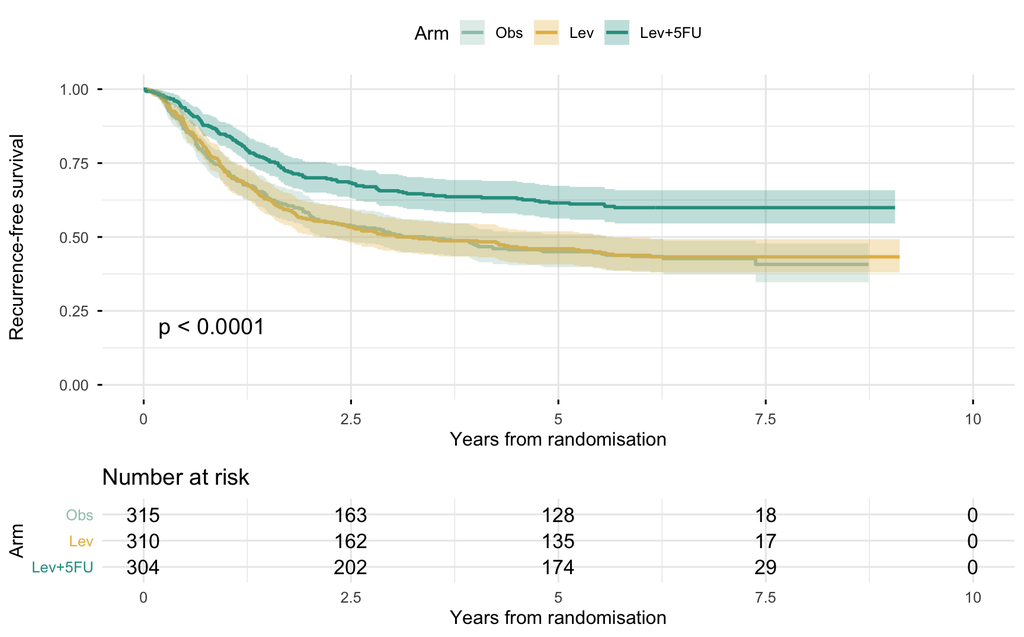

```r
fit_rfs <- survfit(Surv(time_yrs, status) ~ rx, data = rfs)
ggsurvplot(fit_rfs, data = rfs, palette = PAL, conf.int = TRUE,
           risk.table = TRUE, pval = TRUE, censor = FALSE,
           xlab = "Years from randomisation", ylab = "Recurrence-free survival",
           legend.title = "Arm", legend.labs = c("Obs", "Lev", "Lev+5FU"),
           risk.table.height = 0.28, ggtheme = theme_minimal(base_size = 12))
```

A consistent and earlier separation favoured the combination arm for recurrence-free survival, with the curves diverging within the first two years. This pattern indicates that the treatment acts principally by preventing or delaying disease recurrence.

# 4 Cox proportional-hazards model

The Kaplan-Meier curves compare arms on their own. The **Cox model** estimates the effect of treatment while adjusting for prognostic factors, and reports a **hazard ratio (HR)**: the relative rate of death. HR below 1 means lower risk.

```r
cox <- coxph(Surv(time_yrs, status) ~ rx + age + sex + nodes + extent +
               differ + obstruct + perfor, data = os)
ct <- tbl_regression(cox, exponentiate = TRUE,
               add_estimate_to_reference_rows = TRUE,
               label = list(rx ~ "Treatment arm", age ~ "Age",
                            sex ~ "Sex", nodes ~ "Positive nodes",
                            extent ~ "Local extent", differ ~ "Differentiation",
                            obstruct ~ "Obstruction", perfor ~ "Perforation")) |>
  modify_caption("**Table 2. Adjusted hazard ratios for death (multivariable Cox model)**")
cat(strip_dash(as_kable(ct)), sep = "\n")
```

**Table 2. Adjusted hazard ratios for death (multivariable Cox model)**

| **Characteristic** | **HR** | **95% CI** | **p-value** |
| --- | --- | --- | --- |
| Treatment arm |  |  |  |
| Obs | 1.00 |  |  |
| Lev | 0.91 | 0.73, 1.14 | 0.4 |
| Lev+5FU | 0.67 | 0.53, 0.86 | 0.001 |
| Age | 1.01 | 1.00, 1.02 | 0.090 |
| Sex |  |  |  |
| Female | 1.00 |  |  |
| Male | 0.98 | 0.81, 1.18 | 0.8 |
| Positive nodes | 1.09 | 1.07, 1.11 | <0.001 |
| Local extent |  |  |  |
| Contiguous | 1.00 |  |  |
| Muscle | 0.42 | 0.25, 0.71 | 0.001 |
| Serosa | 0.71 | 0.46, 1.07 | 0.10 |
| Submucosa | 0.22 | 0.06, 0.72 | 0.013 |
| Differentiation |  |  |  |
| Moderate | 1.00 |  |  |
| Poor | 1.35 | 1.05, 1.73 | 0.018 |
| Well | 1.09 | 0.79, 1.52 | 0.6 |
| Obstruction |  |  |  |
| No | 1.00 |  |  |
| Yes | 1.26 | 1.00, 1.60 | 0.051 |
| Perforation |  |  |  |
| No | 1.00 |  |  |
| Yes | 1.05 | 0.62, 1.77 | 0.9 |

```r
hr <- tidy(cox, exponentiate = TRUE, conf.int = TRUE) |>
  filter(term == "rxLev+5FU")
cat(sprintf("Lev+5FU vs Obs: HR = %.2f (95%% CI %.2f to %.2f), p = %.4f\n",
            hr$estimate, hr$conf.low, hr$conf.high, hr$p.value))
```

```
## Lev+5FU vs Obs: HR = 0.67 (95% CI 0.53 to 0.86), p = 0.0012
```

After adjustment for age, sex, nodal burden, local extent, tumour differentiation, obstruction and perforation, levamisole plus fluorouracil remained associated with a significantly reduced hazard of death relative to observation (adjusted HR 0.67; 95% CI, 0.53 to 0.86; P = 0.001), corresponding to an approximately one third lower rate of death. Levamisole alone showed no significant effect. The number of positive lymph nodes and the local extent of the tumour were the strongest independent prognostic factors, consistent with established clinical knowledge.

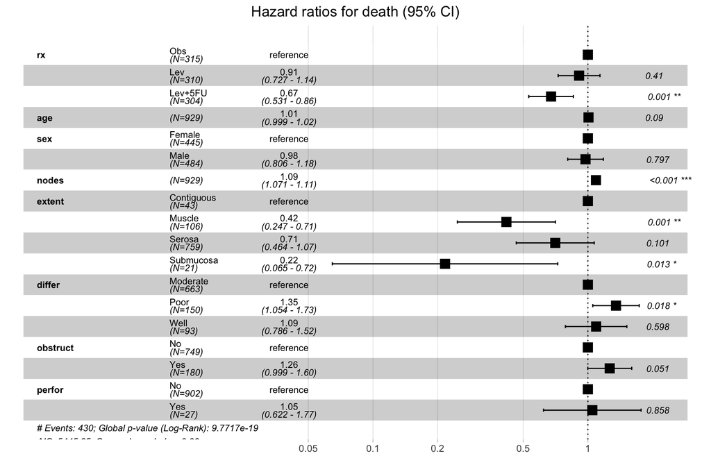

```r
ggforest(cox, data = os, main = "Hazard ratios for death (95% CI)")
```

# 5 Checking the proportional-hazards assumption

The Cox model assumes a treatment’s effect on the hazard is roughly constant over time. We test this with scaled Schoenfeld residuals.

```r
zph <- cox.zph(cox)
print(zph)
```

```
##            chisq df       p
## rx        2.9209  2 0.23213
## age       1.1807  1 0.27722
## sex       0.3537  1 0.55202
## nodes     0.0203  1 0.88662
## extent    7.1654  3 0.06681
## differ   16.8839  2 0.00022
## obstruct  6.8003  1 0.00911
## perfor    0.5598  1 0.45434
## GLOBAL   37.9215 12 0.00016
```

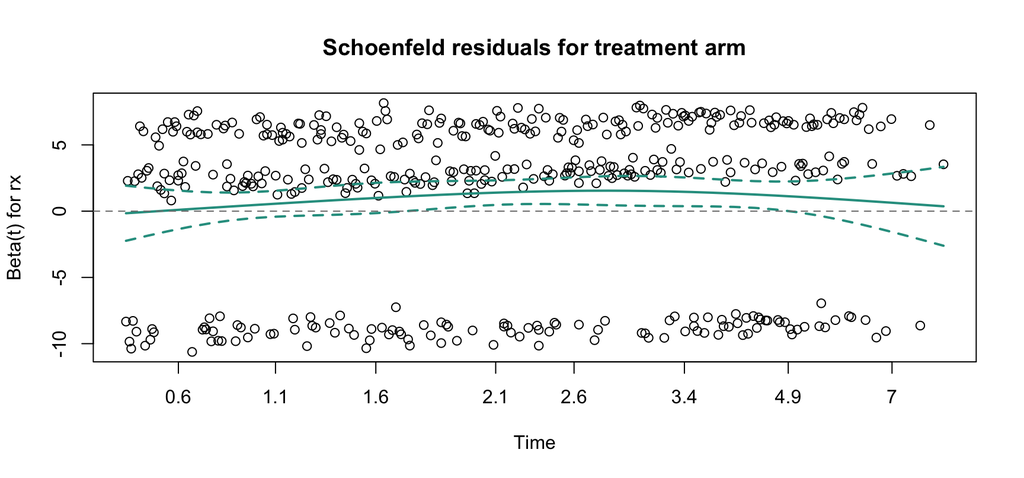

```r
plot(zph[1], col = ACC, lwd = 2)
abline(h = 0, lty = 2, col = "grey50")
title("Schoenfeld residuals for treatment arm")
```